# Pocket TB

## Tracking Tuberculosis (TB) 2020: A Visualization Exploration Featuring Google Search Trend and WHO Global Cases

Shiny app link: https://irenetoo.shinyapps.io/archivev5 Github link : https://github.com/lengtt/The-Tuberculosis-Tracker Video presentation link: https://github.com/lengtt/The-Tuberculosis-Tracker/blob/master/TB%20Tracker%20-%20PocketTB.mkv

Group members:

- Ng Kah Yong (17202174)
- Tan Bing Sin (17218734)
- Teo Teck Guan (17202637)
- Too Ai Leng (17201119)

### About the Project

## Project objective:

To raise awareness and reminds the public that TB remains the no.1 disease killer in the world.

[figure not shown]

Question 1:

1. What is the trend of TB cases from 2004 to 2018?
2. How does the google search interest in TB change over time?

Datasets:

- WHO TB cases: https://www.who.int/tb/data/en
- Google trend search interest: https://trends.google.com/trends/explore?date=all&q=tuberculosis

### Data Science Process

1. Clean datasets
- Check outliers
- Filter unwanted variables
2. Preprocess data
- data wrangling on year and country features
- Data aggregation on selected columns
- filter and select features for EDA
3. Exploratory Data Analysis
   - Search interests trend plots by keywords
   - Wordcloud
   - Streamline chart

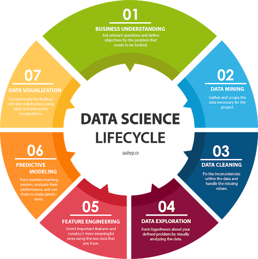

### Visualization

Interactive Map (TB cases from 2004-2018)

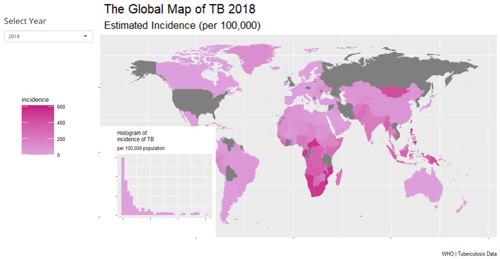

- Countries
- Number of TB cases
- Years

Interactive Stream Graph (TB cases vs Google Search Interest)

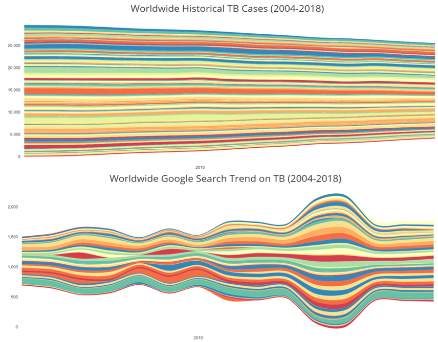

### Findings & Conclusion

Insights

1. No correlation between worldwide TB past cases with Google Search trends related to “Tuberculosis”.
2. Higher concentration of TB cases in Africa continent, as compared to others.
3. Top search terms to related TB:
   - BCG (Bacillus Calmette-Guerin vaccine)
   - mycobacterium

Frameworks/Tools:

R, HTML, CSS, Contemporary charts

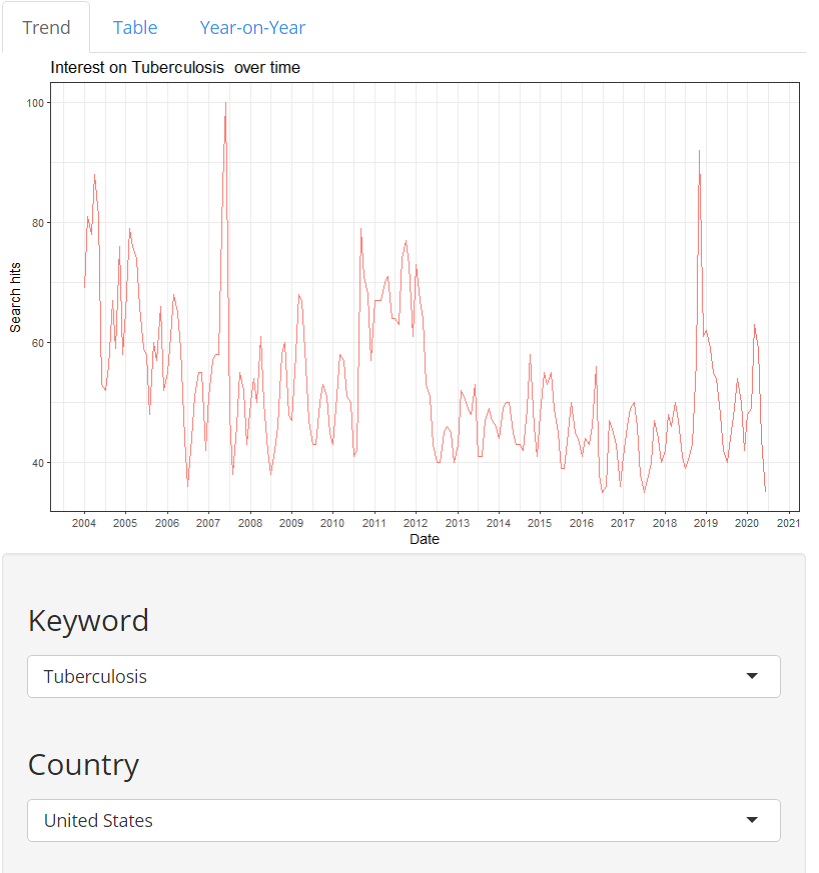